# Метрики регресії · практика> Лекція: lecture.html · Домашнє завдання: homework.html · Тест: quiz.htmlНаскрізний приклад той самий, що й у лекції — **передбачення ціни вживаного телефоназа оголошенням**. Колонки: модель, рік, стан, обсяг памʼяті, ціна.Що зробимо:1. порахуємо MAE, MSE, RMSE, R², MAPE і SMAPE **вручну на NumPy** — рядок за рядком;2. звіримо кожне число зі `sklearn.metrics` — вони мають зійтися до останнього знака;3. зіпсуємо дані одним викидом і подивимось, яка метрика як зреагувала;4. побудуємо дві моделі, на яких MAE і RMSE дають **протилежні** вердикти;5. проженемо все на більшій вибірці зі справжньою лінійною регресією.

```python
import numpy as np
import pandas as pd
import matplotlib.pyplot as plt
from sklearn.metrics import (mean_absolute_error, mean_squared_error,
                             r2_score, mean_absolute_percentage_error)

# фіксуємо генератор випадкових чисел, щоб результат був однаковий у всіх
генератор = np.random.default_rng(42)

print("numpy", np.__version__)
print("pandas", pd.__version__)
print("готово — усі бібліотеки на місці")
```

```
numpy 2.5.1
pandas 2.3.3
готово — усі бібліотеки на місці
```

## 1 · Шість оголошень із лекціїПочинаємо з крихітної таблиці, яку можна перевірити калькулятором. Це важливо:поки числа маленькі, кожну формулу видно наскрізь.Колонка **ціна** — це факт (за скільки телефон реально продали), колонка**прогноз** — те, що назвала модель.

```python
оголошення = pd.DataFrame({
    "модель":   ["Redmi Note 10", "Samsung A52", "Poco X3",
                 "iPhone SE 2020", "Realme 8", "iPhone 11"],
    "рік":      [2021, 2021, 2020, 2020, 2021, 2019],
    "стан":     ["добрий", "добрий", "задовільний", "добрий", "відмінний", "відмінний"],
    "памʼять, ГБ": [128, 128, 64, 128, 128, 64],
    "ціна":     [5200, 7300, 3900, 8100, 6100, 12000],
    "прогноз":  [5600, 6700, 4800, 8500, 6200, 10800],
})

print(оголошення.to_string(index=False))
```

```
        модель  рік        стан  памʼять, ГБ  ціна  прогноз
 Redmi Note 10 2021      добрий          128  5200     5600
   Samsung A52 2021      добрий          128  7300     6700
       Poco X3 2020 задовільний           64  3900     4800
iPhone SE 2020 2020      добрий          128  8100     8500
      Realme 8 2021   відмінний          128  6100     6200
     iPhone 11 2019   відмінний           64 12000    10800
```

## 2 · Помилка одного рядка й чому суму брати не можнаПомилка (residual) — це `факт − прогноз`. Знак має сенс: мінус означає, що модельпереоцінила телефон, плюс — що недооцінила.Зараз побачимо головну пастку: сума помилок дорівнює нулю, хоча модель промахнуласьна **кожному** рядку.

```python
факт = оголошення["ціна"].to_numpy(dtype=float)
прогноз = оголошення["прогноз"].to_numpy(dtype=float)

# помилка окремо для кожного оголошення — щоб побачити не одне число, а розподіл
помилка = факт - прогноз
оголошення["помилка"] = помилка.astype(int)

print(оголошення[["модель", "ціна", "прогноз", "помилка"]].to_string(index=False))
print()
print("сума помилок      :", помилка.sum())
print("сума модулів      :", np.abs(помилка).sum())
print()
print("Сума нульова — але жоден прогноз не влучив. Плюси й мінуси знищили одне одного.")
```

```
        модель  ціна  прогноз  помилка
 Redmi Note 10  5200     5600     -400
   Samsung A52  7300     6700      600
       Poco X3  3900     4800     -900
iPhone SE 2020  8100     8500     -400
      Realme 8  6100     6200     -100
     iPhone 11 12000    10800     1200

сума помилок      : 0.0
сума модулів      : 3600.0

Сума нульова — але жоден прогноз не влучив. Плюси й мінуси знищили одне одного.
```

## 3 · MAE — середня абсолютна помилкаФормула: `MAE = (1/n) · Σ |факт − прогноз|`.Прибираємо знак модулем, складаємо, ділимо на кількість оголошень. Найпростішаметрика з усіх — і найлегша для пояснення замовникові.

```python
# рахуємо руками, крок за кроком — саме так, як у лекції
модулі_помилок = np.abs(помилка)
сума_модулів = модулі_помилок.sum()
наш_mae = сума_модулів / len(факт)

бібліотечний_mae = mean_absolute_error(факт, прогноз)

print("модулі помилок    :", модулі_помилок.astype(int))
print("сума модулів      :", сума_модулів)
print("поділити на", len(факт), "        :", наш_mae)
print()
print("наш MAE           :", наш_mae)
print("sklearn MAE       :", бібліотечний_mae)

assert np.allclose(наш_mae, бібліотечний_mae), "розрахунок розійшовся!"
print("✅ збігається — модель помиляється в середньому на 600 грн")
```

```
модулі помилок    : [ 400  600  900  400  100 1200]
сума модулів      : 3600.0
поділити на 6         : 600.0

наш MAE           : 600.0
sklearn MAE       : 600.0
✅ збігається — модель помиляється в середньому на 600 грн
```

## 4 · MSE і RMSE — те саме, але через квадрат`MSE = (1/n) · Σ (факт − прогноз)²` — середній квадрат помилки. Число виходить у«гривнях у квадраті», тому його не можна прочитати вголос.`RMSE = √MSE` повертає нас у гривні. Зверни увагу: RMSE вийде **більшою** за MAE,бо квадрат непропорційно роздуває великі промахи.

```python
квадрати_помилок = помилка ** 2
наш_mse = квадрати_помилок.mean()
наш_rmse = np.sqrt(наш_mse)

бібліотечний_mse = mean_squared_error(факт, прогноз)

print("квадрати помилок  :", квадрати_помилок.astype(int))
print("сума квадратів    :", квадрати_помилок.sum())
print()
print("наш MSE           :", наш_mse, "(гривень у квадраті — не читається)")
print("sklearn MSE       :", бібліотечний_mse)
print("наш RMSE          :", наш_rmse, "грн")
print()
# найбільший квадрат показує, скільки важить один-єдиний поганий прогноз
частка_найбільшого = квадрати_помилок.max() / квадрати_помилок.sum()
print(f"найгірший рядок дає {частка_найбільшого:.1%} усієї суми квадратів")

assert np.allclose(наш_mse, бібліотечний_mse), "розрахунок розійшовся!"
print("✅ збігається")
```

```
квадрати помилок  : [ 160000  360000  810000  160000   10000 1440000]
сума квадратів    : 2940000.0

наш MSE           : 490000.0 (гривень у квадраті — не читається)
sklearn MSE       : 490000.0
наш RMSE          : 700.0 грн

найгірший рядок дає 49.0% усієї суми квадратів
✅ збігається
```

## 5 · R² — порівняння з «завжди називаю середнє»MAE в гривнях не каже, добре це чи погано: усе залежить від масштабу цін. R² прибираєодиниці, порівнюючи нашу модель із найдурнішою можливою — тією, що завжди називаєсередню ціну.`R² = 1 − SSres / SStot`, де `SSres = Σ(факт − прогноз)²`, а `SStot = Σ(факт − середнє)²`.

```python
середня_ціна = факт.mean()

ss_res = ((факт - прогноз) ** 2).sum()          # помилка нашої моделі
ss_tot = ((факт - середня_ціна) ** 2).sum()      # помилка моделі «завжди середнє»
наш_r2 = 1 - ss_res / ss_tot

бібліотечний_r2 = r2_score(факт, прогноз)

print("середня ціна      :", середня_ціна)
print("SSres (наша модель):", ss_res)
print("SStot (середнє)   :", ss_tot)
print()
print("наш R²            :", наш_r2)
print("sklearn R²        :", бібліотечний_r2)

assert np.allclose(наш_r2, бібліотечний_r2), "розрахунок розійшовся!"
print(f"✅ збігається — модель пояснює {наш_r2:.1%} розкиду цін")
```

```
середня ціна      : 7100.0
SSres (наша модель): 2940000.0
SStot (середнє)   : 39900000.0

наш R²            : 0.9263157894736842
sklearn R²        : 0.9263157894736842
✅ збігається — модель пояснює 92.6% розкиду цін
```

### R² буває відʼємнимЦе не помилка й не рідкість. Якщо модель гірша за просте середнє, `SSres > SStot`, ідріб перевищує одиницю. Перевіримо на моделі, яка вперто називає 10 000 грн для всіх.

```python
уперта_модель = np.full(len(факт), 10000.0)   # завжди 10 000 грн, хай там що

print("R² моделі «завжди середнє»:", round(r2_score(факт, np.full(len(факт), середня_ціна)), 4))
print("R² моделі «завжди 10 000» :", round(r2_score(факт, уперта_модель), 4))
print()
print("Нуль означає «не краще за середнє», відʼємне число — «гірше за середнє».")
```

```
R² моделі «завжди середнє»: 0.0
R² моделі «завжди 10 000» : -1.2647

Нуль означає «не краще за середнє», відʼємне число — «гірше за середнє».
```

## 6 · MAPE і SMAPE — відсотки замість гривень`MAPE = (1/n) · Σ |факт − прогноз| / факт` — помилку кожного рядка ділимо на **йоговласну** ціну. Так промах у 600 грн на телефоні за 12 000 і на телефоні за 1 500перестають бути однаковими.SMAPE ділить не на факт, а на середнє між фактом і прогнозом. У `sklearn` її немає —напишемо самі.

```python
частки = np.abs(помилка) / факт          # відносна помилка кожного рядка
наш_mape = частки.mean()

бібліотечний_mape = mean_absolute_percentage_error(факт, прогноз)

# SMAPE: у знаменнику середнє між фактом і прогнозом, тому нуль у факті її не ламає
наш_smape = (np.abs(помилка) / ((факт + прогноз) / 2)).mean()

таблиця_відсотків = оголошення[["модель", "ціна", "помилка"]].copy()
таблиця_відсотків["частка"] = (частки * 100).round(2)
print(таблиця_відсотків.to_string(index=False))
print()
print(f"наш MAPE          : {наш_mape:.4%}")
print(f"sklearn MAPE      : {бібліотечний_mape:.4%}")
print(f"наш SMAPE         : {наш_smape:.4%}")

assert np.allclose(наш_mape, бібліотечний_mape), "розрахунок розійшовся!"
print("✅ збігається")
print()
print("Найгірший рядок за MAPE — Poco X3 (23%), хоча за модулем помилки")
print("найгірший був iPhone 11. Метрики питають різне.")
```

```
        модель  ціна  помилка  частка
 Redmi Note 10  5200     -400    7.69
   Samsung A52  7300      600    8.22
       Poco X3  3900     -900   23.08
iPhone SE 2020  8100     -400    4.94
      Realme 8  6100     -100    1.64
     iPhone 11 12000     1200   10.00

наш MAPE          : 9.2610%
sklearn MAPE      : 9.2610%
наш SMAPE         : 8.9400%
✅ збігається

Найгірший рядок за MAPE — Poco X3 (23%), хоча за модулем помилки
найгірший був iPhone 11. Метрики питають різне.
```

## 7 · Одна функція, яка рахує всеДалі метрики знадобляться нам багато разів, тому зберемо їх в одну функцію.Вона повертає звичайний словник — його зручно класти в `DataFrame`.

```python
def усі_метрики(факт, прогноз):
    # Рахує пʼять метрик регресії й повертає їх словником.
    # MAPE ставимо None, якщо серед фактів є нуль: ділення на нуль означає,
    # що метрика просто не існує, а не що вона дорівнює нулю.
    помилка = факт - прогноз
    результат = {
        "MAE": np.abs(помилка).mean(),
        "MSE": (помилка ** 2).mean(),
        "RMSE": np.sqrt((помилка ** 2).mean()),
        "R2": r2_score(факт, прогноз),
        "SMAPE, %": (np.abs(помилка) / ((np.abs(факт) + np.abs(прогноз)) / 2)).mean() * 100,
    }
    if np.any(факт == 0):
        результат["MAPE, %"] = None
    else:
        результат["MAPE, %"] = (np.abs(помилка) / факт).mean() * 100
    return результат


базові_метрики = усі_метрики(факт, прогноз)
for назва, значення in базові_метрики.items():
    print(f"{назва:<10} {значення:>12.4f}")
```

```
MAE            600.0000
MSE         490000.0000
RMSE           700.0000
R2               0.9263
SMAPE, %         8.9400
MAPE, %          9.2610
```

## 8 · Одне шахрайське оголошення за 1 грнТепер найцікавіше. Додамо сьомий рядок: телефон, виставлений за **1 грн** — типовешахрайське оголошення «пишіть у месенджер». Модель, дивлячись на характеристики,оцінила його у 6 000 грн.Модель ми не переучуємо. Змінюються лише дані — і подивимось, що станеться з кожною метрикою.

```python
факт_із_викидом = np.append(факт, 1.0)          # ціна оголошення — 1 гривня
прогноз_із_викидом = np.append(прогноз, 6000.0)  # модель нічого не запідозрила

метрики_з_викидом = усі_метрики(факт_із_викидом, прогноз_із_викидом)

порівняння = pd.DataFrame({
    "шість чесних": базові_метрики,
    "плюс 1 грн": метрики_з_викидом,
})
порівняння["у скільки разів"] = порівняння["плюс 1 грн"] / порівняння["шість чесних"]

print(порівняння.round(3).to_string())
print()
print("Один рядок із семи. MAE зросла у 2,3 раза, RMSE — у 3,4 раза,")
print("а MAPE злетіла в тисячі разів — бо ділиться на ціну в 1 гривню.")
```

```
          шість чесних   плюс 1 грн  у скільки разів
MAE            600.000     1371.286            2.285
MSE         490000.000  5561143.000           11.349
RMSE           700.000     2358.208            3.369
R2               0.926        0.532            0.574
SMAPE, %         8.940       36.225            4.052
MAPE, %          9.261    85707.938         9254.713

Один рядок із семи. MAE зросла у 2,3 раза, RMSE — у 3,4 раза,
а MAPE злетіла в тисячі разів — бо ділиться на ціну в 1 гривню.
```

```python
# а що буде, якщо ціна взагалі нульова? MAPE перестає існувати
факт_із_нулем = np.append(факт, 0.0)
прогноз_із_нулем = np.append(прогноз, 6000.0)

метрики_з_нулем = усі_метрики(факт_із_нулем, прогноз_із_нулем)
print("MAPE при нульовій ціні :", метрики_з_нулем["MAPE, %"], "← ділення на нуль")
print("RMSE при нульовій ціні :", round(метрики_з_нулем["RMSE"], 1), "грн — рахується спокійно")
```

```
MAPE при нульовій ціні : None ← ділення на нуль
RMSE при нульовій ціні : 2358.6 грн — рахується спокійно
```

## 9 · Дві моделі, два протилежні вердиктиНайважливіший експеримент теми. Візьмемо ті самі шість оголошень і дві різні моделі:* **Обережна** помиляється на кожному оголошенні рівно на 650 грн;* **Ризикова** влучає майже точно на пʼяти (промах 200 грн), але на iPhone 11 промахується на 2 000 грн.MAE і RMSE порахують чесно — і назвуть різних переможців.

```python
обережна = np.array([4550, 7950, 3250, 8750, 5450, 12650], dtype=float)
ризикова = np.array([5000, 7500, 3700, 8300, 5900, 14000], dtype=float)

дві_моделі = pd.DataFrame({
    "Обережна": усі_метрики(факт, обережна),
    "Ризикова": усі_метрики(факт, ризикова),
})
print(дві_моделі.round(3).to_string())
print()

краща_за_mae = дві_моделі.loc["MAE"].idxmin()
краща_за_rmse = дві_моделі.loc["RMSE"].idxmin()
print(f"MAE  обирає : {краща_за_mae}")
print(f"RMSE обирає : {краща_за_rmse}")
print()
if краща_за_mae != краща_за_rmse:
    print("Вердикти протилежні. Метрика не знаходить «кращу модель» —")
    print("вона виконує те визначення кращого, яке ти в неї заклав.")
```

```
            Обережна    Ризикова
MAE          650.000     500.000
MSE       422500.000  700000.000
RMSE         650.000     836.660
R2             0.936       0.895
SMAPE, %      10.714       5.507
MAPE, %       10.361       5.688

MAE  обирає : Ризикова
RMSE обирає : Обережна

Вердикти протилежні. Метрика не знаходить «кращу модель» —
вона виконує те визначення кращого, яке ти в неї заклав.
```

## 10 · Велика вибірка й справжня модельШість рядків добре для розуміння, але метрики міряють на сотнях. Згенеруємо 300оголошень із тими самими колонками, навчимо лінійну регресію й порахуємо метрикина тестовій частині — тобто на даних, яких модель не бачила.

```python
кількість = 300

назви_моделей = генератор.choice(
    ["Redmi Note 10", "Samsung A52", "Poco X3", "iPhone SE 2020", "Realme 8", "iPhone 11"],
    size=кількість)
роки = генератор.integers(2016, 2024, size=кількість)
стани = генератор.choice(["задовільний", "добрий", "відмінний"],
                         size=кількість, p=[0.25, 0.5, 0.25])
обсяги = генератор.choice([64, 128, 256], size=кількість)

# стан переводимо в число: моделі потрібні числа, а не слова
бал_стану = pd.Series(стани).map({"задовільний": 0, "добрий": 1, "відмінний": 2}).to_numpy()

# «справжня» залежність, яку модель має відшукати, плюс шум ринку
ціни = (900
        + 1400 * (роки - 2016)
        + 11 * обсяги
        + 700 * бал_стану
        + генератор.normal(0, 900, size=кількість))
ціни = np.clip(ціни, 500, None).round(-2)     # ціни в оголошеннях круглі

база = pd.DataFrame({
    "модель": назви_моделей, "рік": роки, "стан": стани,
    "памʼять, ГБ": обсяги, "ціна": ціни,
})
print(база.head(8).to_string(index=False))
print()
print("рядків:", len(база), "· ціна від", int(ціни.min()), "до", int(ціни.max()), "грн")
```

```
        модель  рік        стан  памʼять, ГБ    ціна
 Redmi Note 10 2018   відмінний          256  7800.0
      Realme 8 2022 задовільний          128 11700.0
iPhone SE 2020 2016      добрий          256  2400.0
       Poco X3 2023      добрий          256 12900.0
       Poco X3 2020   відмінний          128  8500.0
     iPhone 11 2017      добрий          256  7100.0
 Redmi Note 10 2018      добрий          128  6100.0
      Realme 8 2020      добрий          256 10700.0

рядків: 300 · ціна від 500 до 15400 грн
```

```python
from sklearn.linear_model import LinearRegression
from sklearn.model_selection import train_test_split

ознаки = np.column_stack([роки - 2016, обсяги, бал_стану])

ознаки_навч, ознаки_тест, ціни_навч, ціни_тест = train_test_split(
    ознаки, ціни, test_size=0.3, random_state=42)

модель = LinearRegression().fit(ознаки_навч, ціни_навч)
прогноз_тест = модель.predict(ознаки_тест)

print("коефіцієнти моделі:")
for назва, вага in zip(["рік (від 2016)", "памʼять, ГБ", "бал стану"], модель.coef_):
    print(f"  {назва:<16} {вага:8.1f} грн")
print(f"  вільний член     {модель.intercept_:8.1f} грн")
print()
print("рядків у навчальній вибірці:", len(ціни_навч), "· у тестовій:", len(ціни_тест))
```

```
коефіцієнти моделі:
  рік (від 2016)     1388.6 грн
  памʼять, ГБ           9.5 грн
  бал стану           767.9 грн
  вільний член       1066.7 грн

рядків у навчальній вибірці: 210 · у тестовій: 90
```

```python
метрики_тесту = усі_метрики(ціни_тест, прогноз_тест)
for назва, значення in метрики_тесту.items():
    print(f"{назва:<10} {значення:>12.3f}")
print()
print(f"Читається так: модель помиляється в середньому на {метрики_тесту['MAE']:.0f} грн")
print(f"і пояснює {метрики_тесту['R2']:.1%} розкиду цін на даних, яких не бачила.")
```

```
MAE             790.268
MSE         1046632.012
RMSE           1023.050
R2                0.912
SMAPE, %         11.953
MAPE, %          12.275

Читається так: модель помиляється в середньому на 790 грн
і пояснює 91.2% розкиду цін на даних, яких не бачила.
```

### Розподіл помилок каже більше, ніж одне числоГістограма залишків — найдешевша діагностика, яка є. Здорова модель дає симетричнухмару навколо нуля. Хвіст в один бік означає, що модель систематично завищуєабо занижує ціну.

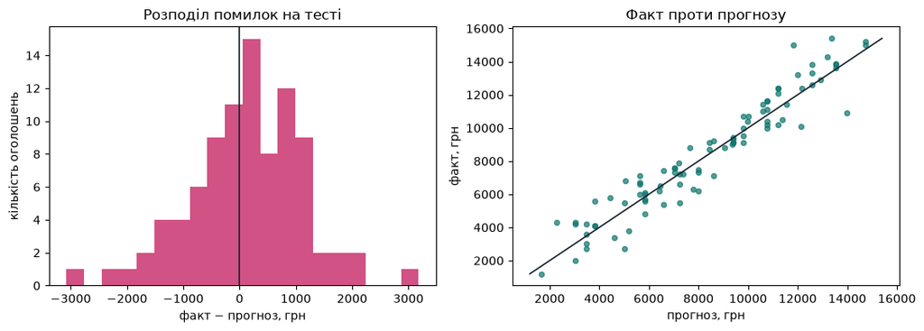

```
середня помилка (перекіс): 120.0 грн
медіанний модуль помилки : 684.4 грн
MAE                      : 790.3 грн

Медіана менша за MAE — отже кілька великих промахів тягнуть середнє вгору.
```

```python
залишки = ціни_тест - прогноз_тест

фігура, осі = plt.subplots(1, 2, figsize=(11, 4))

осі[0].hist(залишки, bins=20, color="#c2185b", alpha=0.75)
осі[0].axvline(0, color="#17212b", linewidth=1.2)
осі[0].set_title("Розподіл помилок на тесті")
осі[0].set_xlabel("факт − прогноз, грн")
осі[0].set_ylabel("кількість оголошень")

осі[1].scatter(прогноз_тест, ціни_тест, s=18, color="#0f766e", alpha=0.7)
межі = [ціни_тест.min(), ціни_тест.max()]
осі[1].plot(межі, межі, color="#17212b", linewidth=1.2)
осі[1].set_title("Факт проти прогнозу")
осі[1].set_xlabel("прогноз, грн")
осі[1].set_ylabel("факт, грн")

plt.tight_layout()
plt.show()

print(f"середня помилка (перекіс): {залишки.mean():.1f} грн")
print(f"медіанний модуль помилки : {np.median(np.abs(залишки)):.1f} грн")
print(f"MAE                      : {np.abs(залишки).mean():.1f} грн")
print()
print("Медіана менша за MAE — отже кілька великих промахів тягнуть середнє вгору.")
```

### Що зробить із цими метриками один викидПовторимо експеримент із лекції на великій вибірці: зіпсуємо **одне** оголошенняз тестової частини, виставивши ціну 1 грн. Модель не переучуємо.

```python
ціни_зіпсовані = ціни_тест.copy()
ціни_зіпсовані[0] = 1.0                # одне шахрайське оголошення з 90

до = усі_метрики(ціни_тест, прогноз_тест)
після = усі_метрики(ціни_зіпсовані, прогноз_тест)

ефект = pd.DataFrame({"до": до, "після одного викиду": після})
ефект["у скільки разів"] = ефект["після одного викиду"] / ефект["до"]
print(ефект.round(3).to_string())
print()
print("Один рядок із", len(ціни_тест), "— а MAPE вже непридатна для звіту.")
```

```
                   до  після одного викиду  у скільки разів
MAE           790.268              903.590            1.143
MSE       1046632.012          2331921.495            2.228
RMSE         1023.050             1527.063            1.493
R2              0.912                0.816            0.894
SMAPE, %       11.953               14.114            1.181
MAPE, %        12.275            11979.380          975.929

Один рядок із 90 — а MAPE вже непридатна для звіту.
```